# Grade Distribution Demographics

Christopher Bragg

CSI

November 2021

## Objective and Methodology

The Dean’s at the College of Southern Idaho have requested each instructor to receive a personalized report that outlines grade distributions for their sections over the last five years, with an emphasis at examining various demographic differences. **The objective is reflection and getting the conversation started, not statistical significance.**

Each instructor will receive:

- An overview of their grade distribution over the last five years
- A collective comparison to the prefixes they have taught in those five years
- A comparison to CSI overall

Only enrollments that resulted in an A, B, C, D, F or W will be included. Add/drops prior to the add/drop date will be excluded. To avoid duplication, especially at the campus-wide level where Labs are handled in a variety of ways, Lab enrollments are excluded as well. Dual credit sections are excluded from the analysis.

## Questions to Ponder

When comparing your students’ grade distribution against grade distribution from others who teach in the same prefix areas, do you see differences that you would consider to be significant? To what might you attribute those differences? How about when comparing your students’ grade distribution against CSI grade distribution as a whole?

When comparing your students’ grade distribution by demographics, do you see differences within the performance of your own students that you would consider to be significant? To what might you attribute those differences?

Attributing a direct causal link to any variations in student performance is challenging. After reviewing your data, what questions do you have about student performance in your courses, or at CSI overall?

## Sections and Enrollments Included

| Academic Year | Semester | Course | Enrollments |
| --- | --- | --- | --- |
| 2017-18 | Spring | COMM 209 C03 | 15 |
| 2018-19 | Fall | COMM 209 C03 | 12 |
| 2018-19 | Spring | COMM 209 C03 | 10 |
| 2019-20 | Fall | COMM 101 C17 | 24 |
| 2019-20 | Fall | COMM 209 C03 | 23 |
| 2019-20 | Spring | COMM 209 C03 | 22 |
| 2020-21 | Fall | COMM 209 C03 | 23 |
| 2020-21 | Spring | COMM 209 C02 | 17 |

## Overall

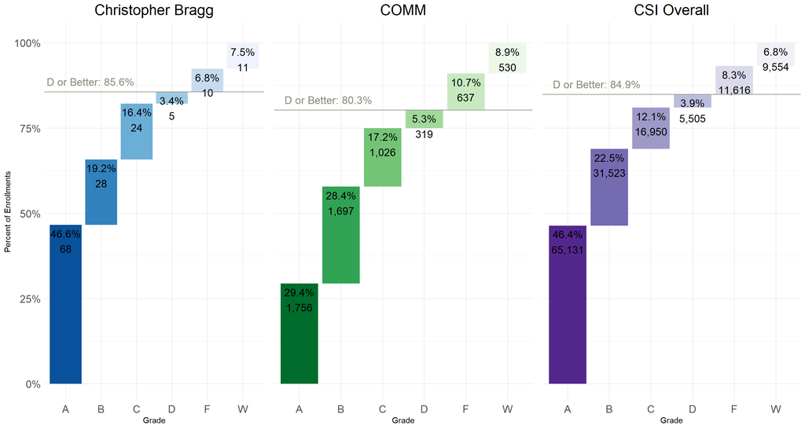

## Demographics

### First Generation

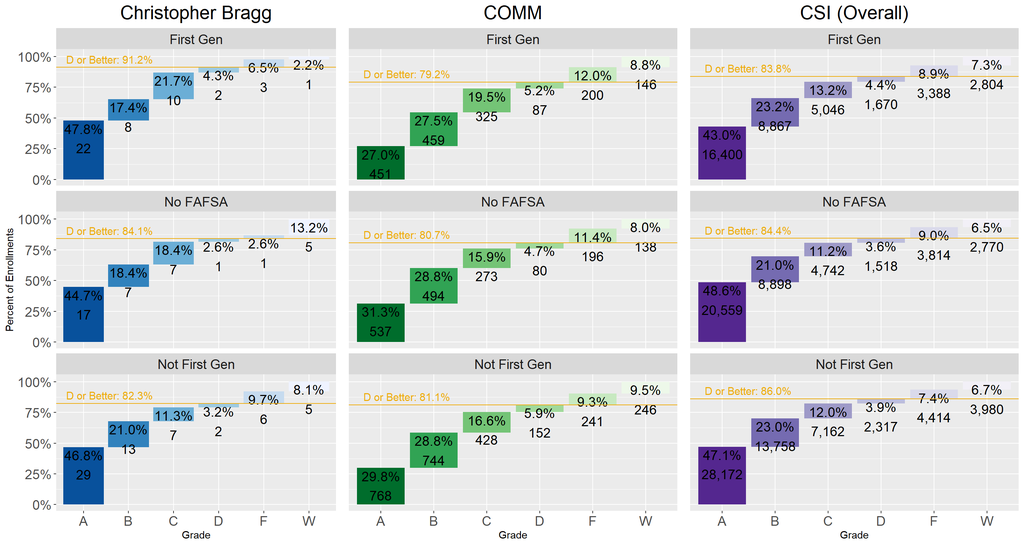

### Pell Eligiblity

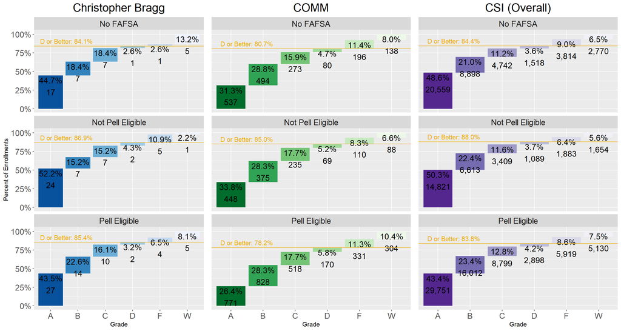

### Gender

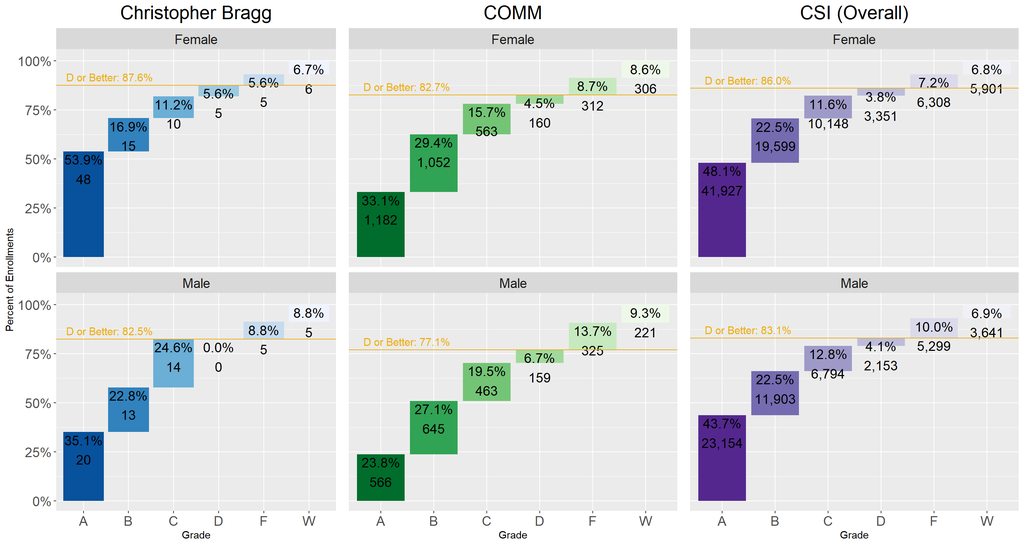

### Race/Ethnicity

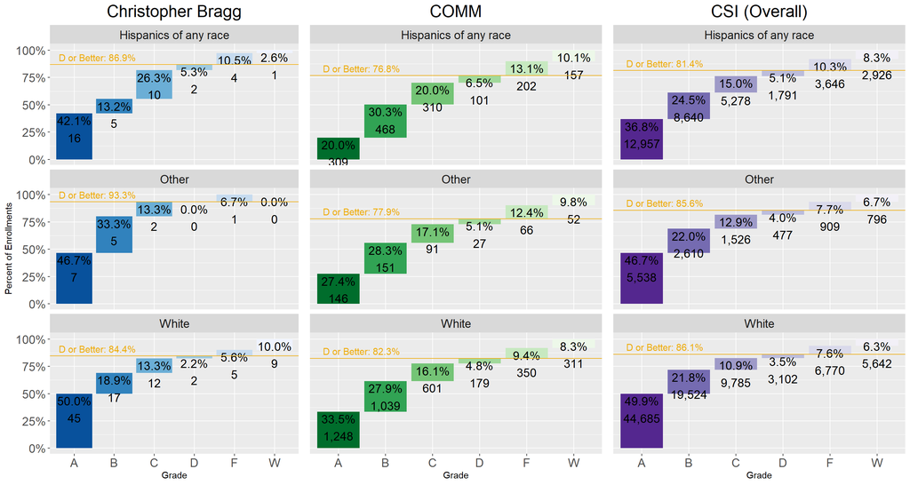

### Age

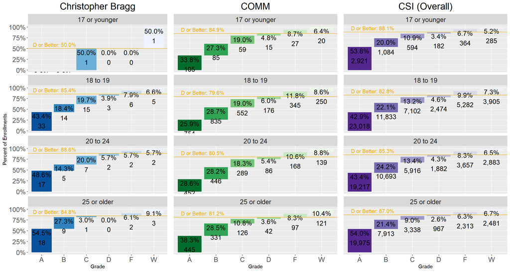